# FITC analysis script - round 4

Kaare

2022-10-17

# Introduction to script

This script is useful for analyzing intestinal permeability from FITC-Dextran assays.

Required data structure is a wide tibble (column headers = variables, samples and values = rows).

This script is per default set to handle ileum and serum expression, although any tissue will work. This will just require resetting of the “tissue”-variable.

# FITC for experiment 4.

### Basic data structure and results table.

First you load the data and check the structure. Make sure cytokine concentrations are all numeric (). If not, mutate non-numeric columns with mutate_if(is_character).

```
## Rows: 80
## Columns: 11
## $ sample_id            <dbl> 33, 34, 35, 36, 37, 38, 40, 41, 42, 43, 44, 45, 4…
## $ exp_number           <dbl> 2, 2, 2, 2, 2, 2, 2, 2, 2, 2, 2, 2, 2, 2, 2, 2, 3…
## $ received_antibiotics <chr> "Yes", "Yes", "Yes", "Yes", "Yes", "Yes", "Yes", …
## $ group2               <chr> "VANCO-BF", "VANCO-BF", "VANCO-BF", "VANCO-BF", "…
## $ maternal_treatment   <chr> "VANCO", "VANCO", "VANCO", "VANCO", "VANCO", "VAN…
## $ type_of_feed         <chr> "BF", "BF", "BF", "BF", "BF", "BF", "BF", "BF", "…
## $ group                <chr> "Vanco+Breastmilk", "Vanco+Breastmilk", "Vanco+Br…
## $ µl_serum             <dbl> 12.5, 12.5, 25.0, 25.0, 25.0, 12.5, 25.0, 25.0, 1…
## $ dilution_factor      <dbl> 8, 8, 4, 4, 4, 8, 4, 4, 8, 4, 4, 4, 4, 4, 4, 8, 4…
## $ `result_µg/ml`       <dbl> 0.256, 0.452, 1.159, 0.353, 1.458, 0.361, 2.234, …
## $ values               <dbl> 2.048, 3.616, 4.636, 1.412, 5.832, 2.888, 8.936, …
```

Check for data distribution.

Exclude outliers

Below is a table of the levels of intestinal permeability measurable as the concentration of fitc-dextran in serum for each of the experimental groups.

The values will be displayed as mean + sd if normally distributed or median + IQR if not. An appropriate statistical test for differences will be performed (student-t for two, normally distributed groups, Anova for more than 2 groups, Kruskal wallis for non-normally distrubuted results.)

```r
tbl1 <- fitc %>%
  filter(exp_number == 4) %>%
  mutate(Log10_values = log10(values)) %>%
  select(group, values, Log10_values) %>%
  tbl_summary(by = group,
              digits = everything() ~ c(2,1,1),
              missing = "no",
              #type = list(values ~ 'continuous2', Log10_values ~ 'continuous2'),
              statistic = list(values ~ "{median} ({p25}, {p75})", Log10_values ~"{median} ({p25}, {p75})"),
              label = list(values ~ "µg/mL", Log10_values ~ "Log transformed")) %>%
  add_p(list(values ~ "kruskal.test", Log10_values ~ "kruskal.test")) %>%
  # modify_table_styling(
  #   columns = label,
  #   rows = label == "µg/mL",
  #   footnote = "Non-parametric distribution"
  # ) %>%
  modify_header(
    label = "FITC Conc.",
    stat_1 = "**VANCO-BF (CON)**\n(n = {n})",
    stat_2 = "**VANCO-FF (FVT)**\n(n = {n})",
    stat_3 = "**VANCO-FF (SM)**\n(n = {n})") %>%
  modify_spanning_header((c("stat_1", "stat_2", "stat_3") ~ "Treatment groups (N total = {N})")) %>%
  bold_labels()

tbl1_gt <- tbl1 %>%
 as_gt(include = -tab_footnote) %>%
  tab_footnote(
    footnote = md("Log transformation did not normalize distribution.  \n  Non-parametric test (Kruskall-Wallis) used for both datasets."),
    locations = cells_column_labels(columns = c(p.value))
  ) %>%
  tab_header(title = md("**Intestinal permeability**")) %>%
  opt_align_table_header("center") %>%
  tab_options(heading.title.font.size = 20,
              heading.background.color = "lightgrey"
              ) %>%
  # tab_source_note(
  #   source_note = " µg/mL values"
  # ) %>%
  tab_source_note(
    source_note = md("**Matrinem round 4**")
  ) %>%
  cols_width(label ~ px(100),
             stat_1 ~ px(150),
             stat_2 ~ px(150),
             stat_3 ~ px(150))
tbl1_gt
```

**Intestinal permeability**

[output not shown]

**Matrinem round 4**  
<sup>1</sup> Log transformation did not normalize distribution. Non-parametric test (Kruskall-Wallis) used for both datasets.

```r
# tbl1_gt %>%
#   gtsave("../../Results/Round 4/FITC table round 3 TEST.png", expand = 50) #use .tex for latex files
```

```r
tbl1_p <- tbl1 %>%
  filter_p() %>%
  as_tibble()
```

### Plots and regression models

First the data must be transformed to a long format (pivot longer). Mutate any new columns with group treatments needed for the regression model (in this case MAT and FEED (experimental factors)).

```
## # A tibble: 6 × 12
##   sample_id exp_number received_antibiotics group2 maternal_treatm… type_of_feed
##       <dbl>      <dbl> <chr>                <chr>  <chr>            <chr>
## 1        89          4 Yes                  VANCO… VANCO            FF
## 2        90          4 Yes                  VANCO… VANCO            FF
## 3        91          4 Yes                  VANCO… VANCO            FF
## 4        92          4 Yes                  VANCO… VANCO            FF
## 5        93          4 Yes                  VANCO… VANCO            FF
## 6        94          4 Yes                  VANCO… VANCO            FF
## # … with 6 more variables: group <fct>, µl_serum <dbl>, dilution_factor <dbl>,
## #   `result_µg/ml` <dbl>, values <dbl>, Log10_values <dbl>
```

Create a comparison vector to see pariwise comparisons.

```r
my_comparisons <- list(c("VANCO-BF", "VANCO-FF (FVT)"), c("VANCO-BF", "VANCO-FF (SM)"), c("VANCO-FF (FVT)", "VANCO-FF (SM)"))
```

Boxplots with jitter - normal values

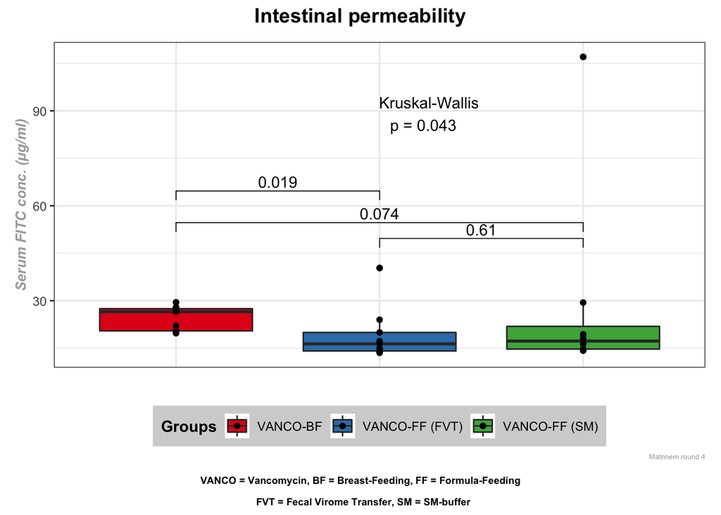

```r
plot_all_fitc <- fitc_long %>%
ggplot(aes(x = group,
           y = values,
           fill = group)) +
  geom_boxplot() +
  geom_point() +
  #coord_cartesian(ylim = c(1.5, 16)) +
  stat_compare_means(comparisons = my_comparisons, label.y = c(60, 50, 45), method = "wilcox.test") +
  stat_compare_means(aes(label = paste0("Kruskal-Wallis \n p = ", ..p.format..)),
    label.y.npc = 0.75,
    label.x.npc = 0.55) +
  labs( # Change title, and axis names
       x = "",
       y = "Serum FITC conc. (µg/ml)",
       fill = "Groups",
       caption = "Matrinem round 4") +
  theme_bw()+
  theme(                   # Change the appearance of labels
    plot.title = element_text(color="darkgrey", size=12, face="bold"),
    axis.title.y = element_text(color="darkgrey", size=10, face="bold.italic"),
    #axis.text.y = element_blank(),
    axis.ticks.x = element_blank(),  # Hide labels
    axis.text.x = element_blank(),
    legend.title = element_text(face="bold"),
    legend.position="bottom",
    legend.background = element_rect(fill="lightgrey"),#Change legend box background color
    plot.caption = element_text(color = "darkgrey", size=5)) +
  scale_fill_brewer(palette="Set1")

all_fitc_patch <- plot_all_fitc + plot_annotation (
  title = 'Intestinal permeability',
   #subtitle = 'All fitc measured',
  #tag_levels = 'A',
  caption = 'VANCO = Vancomycin, BF = Breast-Feeding, FF = Formula-Feeding\n
  FVT = Fecal Virome Transfer, SM = SM-buffer',
  theme = theme(plot.title = element_text(hjust = 0.5, size=14, face="bold"),
                plot.subtitle = element_text(hjust = 0.5, face = "bold.italic"),
                plot.caption = element_text(hjust = 0.5, size=7,face = "bold")))

all_fitc_patch
```

```r
#ggsave('../../Results/Round 3/FITC boxplots.png',all_fitc_patch)
```

Log transformed values

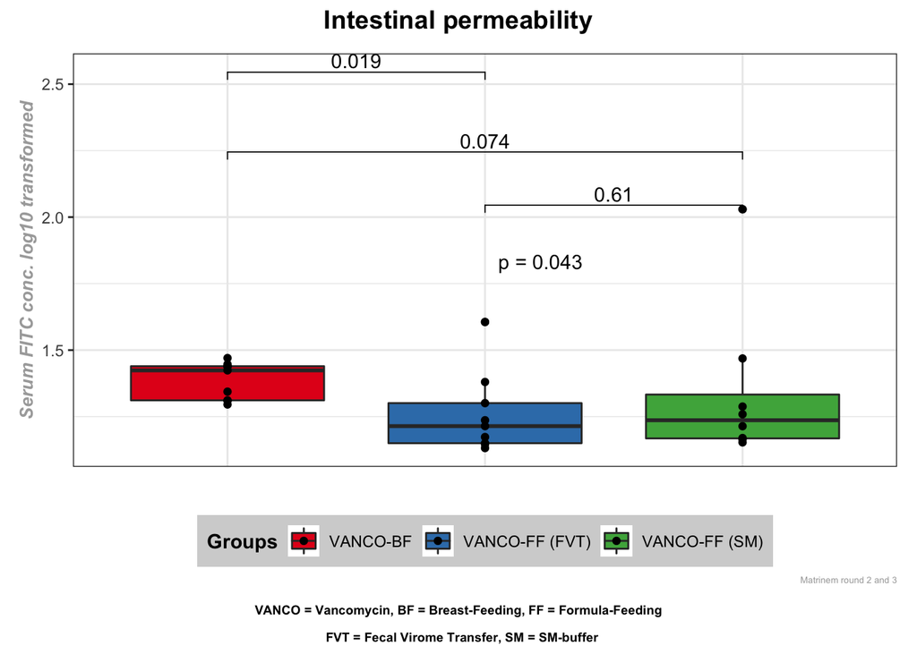

```r
plot_all_fitc_log10 <- fitc_long %>%
ggplot(aes(x = group,
           y = Log10_values,
           fill = group)) +
  geom_boxplot() +
  geom_point() +
  #coord_cartesian(ylim = c(1.5, 16)) +
  stat_compare_means(comparisons = my_comparisons, label.y = c(2.5, 2.2, 2), method = "wilcox.test")+
  stat_compare_means(aes(label = paste0("\n p = ", ..p.format..)),
    label.y.npc = 0.75,
    label.x.npc = 0.55) +
  labs( # Change title, and axis names
       x = "",
       y = "Serum FITC conc. log10 transformed",
       fill = "Groups",
       caption = "Matrinem round 2 and 3") +
  theme_bw()+
  theme(                   # Change the appearance of labels
    plot.title = element_text(color="darkgrey", size=12, face="bold"),
    axis.title.y = element_text(color="darkgrey", size=10, face="bold.italic"),
    #axis.text.y = element_blank(),
    axis.ticks.x = element_blank(),  # Hide labels
    axis.text.x = element_blank(),
    legend.title = element_text(face="bold"),
    legend.position="bottom",
    legend.background = element_rect(fill="lightgrey"),#Change legend box background color
    plot.caption = element_text(color = "darkgrey", size=5)) +
  scale_fill_brewer(palette="Set1")

all_fitc_patch_log10 <- plot_all_fitc_log10 + plot_annotation (
  title = 'Intestinal permeability',
   #subtitle = 'All fitc measured',
  #tag_levels = 'A',
  caption = 'VANCO = Vancomycin, BF = Breast-Feeding, FF = Formula-Feeding\n
  FVT = Fecal Virome Transfer, SM = SM-buffer',
  theme = theme(plot.title = element_text(hjust = 0.5, size=14, face="bold"),
                plot.subtitle = element_text(hjust = 0.5, face = "bold.italic"),
                plot.caption = element_text(hjust = 0.5, size=7,face = "bold")))

all_fitc_patch_log10
```

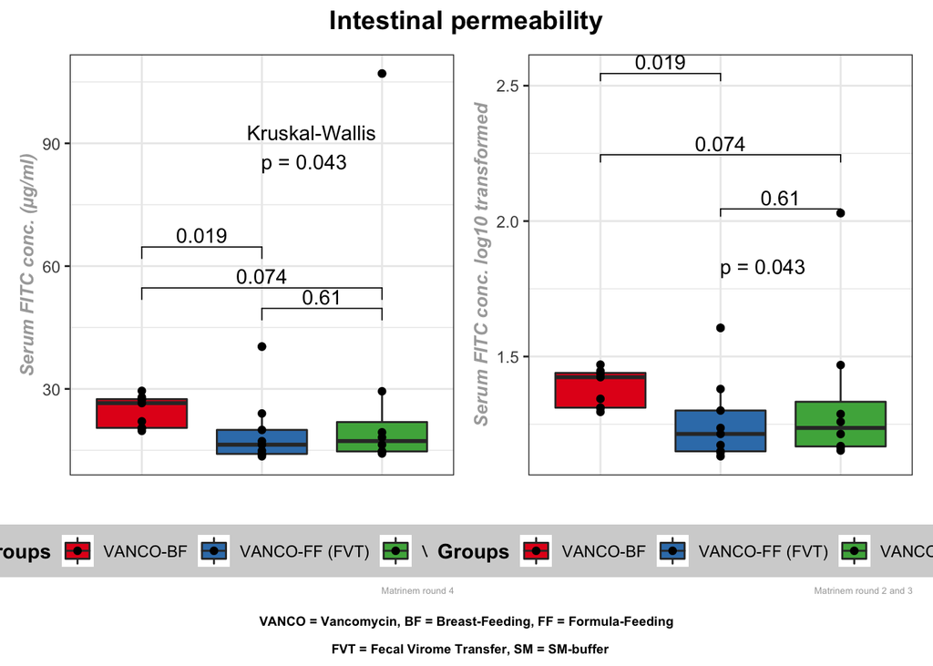

```r
ggsave('../../Results/Round 4/FITC boxplot log 10.png',all_fitc_patch_log10)
FITC_PATCH <- all_fitc_patch + all_fitc_patch_log10
FITC_PATCH
```